# League of Legends: O impacto do foco nos objetivos.

Matheus Alves dos Santos

05 de julho de 2019

O **League of Legends**, muitas vezes referenciado apenas por LOL, é um jogo eletrônico do gênero MOBA (*Multiplayer Online Battle Arena*) desenvolvido pela Riot Games. Em *League of Legends*, os jogadores são divididos em times e, assumindo o papel de invocadores, controlam campeões com habilidades únicas para enfrentar os times adversários. Bem recebido desde seu lançamento em 2009, LOL é o jogo para computador mais popular da atualidade, cujo cenário competitivo é grande o suficiente para entregar premiações milionárias anualmente.

Em seu modo mais popular, o objetivo dos dois times é destruir o *Nexus* da equipe adversária, uma estrutura localizada na base inimiga e protegida por outras estruturas (como inibidores e torres). Ainda que a destruição de um dos *Nexus* determine a vitória, destruir outras estruturas e conquistar os objetivos da selva (como os Dragões, o Arauto do Vale e o Barão Nashor) também garante *gold* e *buffs* aos times.

Em teoria, os objetivos deveriam ser a prioridade máxima dos jogadores, porém, o ímpeto de matar os campeões inimigos pode ser uma distração bem grande, especialmente para os jogadores mais inexperientes. Por isso, decidiu-se investigar o real impacto da priorização dos objetivos no resultado das partidas de *League of Legends*.

## Preparação do Ambiente

Para as análises apresentadas a seguir, foram utilizadas as bibliotecas **broom**, **ggplot2**, **modelr**, **tidyverse** e **pscl**. Os dados utilizados são referentes a 50295 partidas ranqueadas da 9º temporada do *League of Legends* e trazem informações sobre qual dos times conquistou o primeiro de cada um dos objetivos do jogo, além de qual deles foi vitorioso.

Foram removidas as partidas com menos de 5 minutos de duração, pois são encerradas precocemente devido à ociosidade de jogadores desde o início da partida. Os dados estão estruturados da seguinte maneira:

```r
ranked_matches <- read_csv(here::here("data/matches_data.csv"))

ranked_matches <- ranked_matches %>%
  mutate(winner = if_else(winner == 1, "Blue", "Red")) %>%
  mutate(first_tower = if_else(first_tower == 1, "Blue", "Red")) %>%
  mutate(first_inhibitor = if_else(first_inhibitor == 1, "Blue", "Red")) %>%
  mutate(first_baron = case_when(first_baron == 0 ~ "None", first_baron == 1 ~ "Blue", first_baron == 2 ~ "Red")) %>%
  mutate(first_dragon = case_when(first_dragon == 0 ~ "None", first_dragon == 1 ~ "Blue", first_dragon == 2 ~ "Red")) %>%
  mutate(rift_herald_kill = case_when(rift_herald_kill == 0 ~ "None", rift_herald_kill == 1 ~ "Blue", rift_herald_kill == 2 ~ "Red"))

ranked_matches <- ranked_matches %>%
  filter(game_duration > 300) %>%
  select(winner, first_tower, first_inhibitor, first_baron, first_dragon, rift_herald_kill)

ranked_matches_factor <- ranked_matches %>%
  mutate(winner = factor(winner, levels = c("Red", "Blue"), ordered = T),
         first_tower = factor(first_tower),
         first_inhibitor = factor(first_inhibitor),
         first_baron = factor(first_baron),
         first_dragon = factor(first_dragon),
         rift_herald_kill = factor(rift_herald_kill))

ranked_matches
```

| winner | first_tower | first_inhibitor | first_baron | first_dragon | rift_herald_kill |
| --- | --- | --- | --- | --- | --- |
| Blue | Blue | Blue | Blue | Blue | Red |
| Blue | Blue | Blue | None | Blue | Blue |
| Blue | Blue | Blue | Blue | Red | None |
| Blue | Blue | Blue | Blue | Blue | None |
| Blue | Blue | Blue | Blue | Blue | None |
| Blue | Red | Blue | Blue | Red | None |
| Blue | Red | Blue | Blue | Blue | Blue |
| Blue | Blue | Red | None | Red | Blue |
| Red | Red | Red | None | Red | Red |
| Red | Red | Red | Red | Red | None |

[output cut: 9990 more lines]

## Relações entre as Variáveis

Antes de analisar a associação entre o time vitorioso de cada partida e sua capacidade de conquistar os objetivos iniciais do jogo, é necessário avaliar como se dá a associação entre essas variáveis. Nesse sentido, abaixo são apresentados alguns gráficos que permitem visualizar as relações entre as variáveis de interesse.

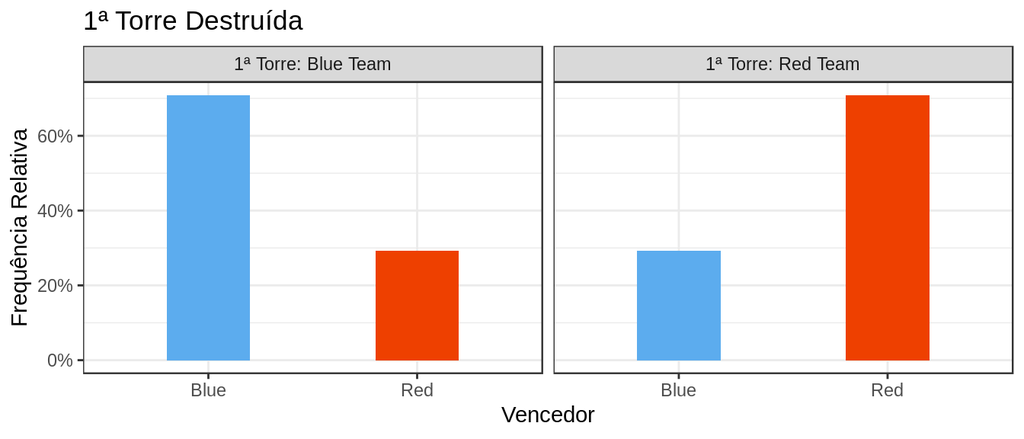

```r
color_scale_2 <- c("steelblue2", "orangered2")

ranked_matches %>%
  mutate(first_tower = if_else(first_tower == "Blue", "1ª Torre: Blue Team", "1ª Torre: Red Team")) %>%
  ggplot(aes(x = winner, y = ..prop.., group = first_tower)) +
  geom_bar(aes(fill = factor(..x..)), width = .4, show.legend = FALSE) +
  labs(x = "Vencedor", y = "Frequência Relativa", title = "1ª Torre Destruída") +
  scale_y_continuous(labels = scales::percent_format(5L)) +
  scale_fill_manual(values = color_scale_2) +
  facet_grid(~ first_tower)
```

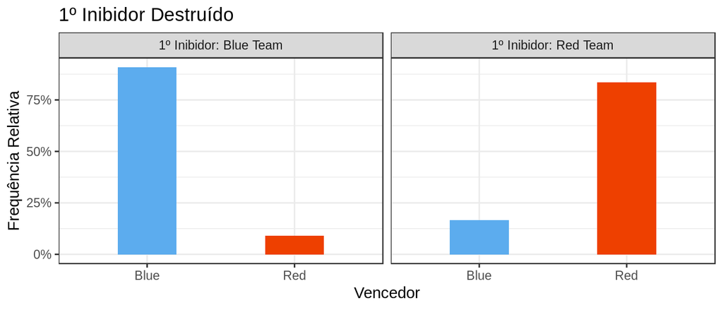

```r
ranked_matches %>%
  mutate(first_inhibitor = if_else(first_inhibitor == "Blue", "1º Inibidor: Blue Team", "1º Inibidor: Red Team")) %>%
  ggplot(aes(x = winner, y = ..prop.., group = first_inhibitor)) +
  geom_bar(aes(fill = factor(..x..)), width = .4, show.legend = FALSE) +
  labs(x = "Vencedor", y = "Frequência Relativa", title = "1º Inibidor Destruído") +
  scale_y_continuous(labels = scales::percent_format(5L)) +
  scale_fill_manual(values = color_scale_2) +
  facet_grid(~ first_inhibitor)
```

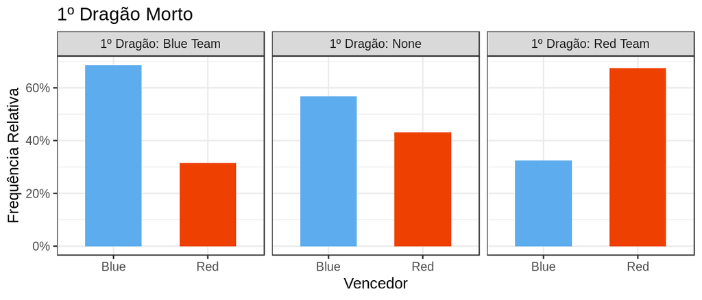

```r
ranked_matches %>%
  mutate(first_dragon = case_when(first_dragon == "Blue" ~ "1º Dragão: Blue Team",
                                   first_dragon == "Red" ~ "1º Dragão: Red Team",
                                   TRUE ~ "1º Dragão: None")) %>%
  ggplot(aes(x = winner, y = ..prop.., group = first_dragon)) +
  geom_bar(aes(fill = factor(..x..)), width = .6, show.legend = FALSE) +
  labs(x = "Vencedor", y = "Frequência Relativa", title = "1º Dragão Morto") +
  scale_y_continuous(labels = scales::percent_format(5L)) +
  scale_fill_manual(values = color_scale_2) +
  facet_grid(~ first_dragon)
```

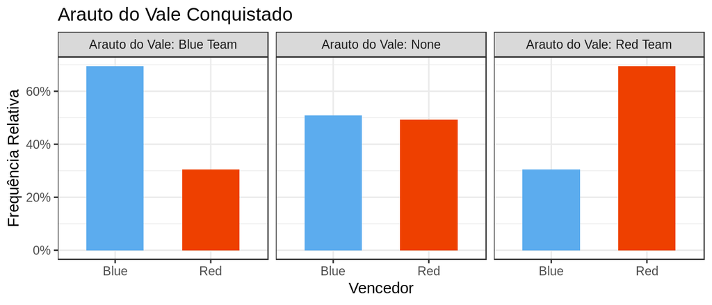

```r
ranked_matches %>%
  mutate(rift_herald_kill = case_when(rift_herald_kill == "Blue" ~ "Arauto do Vale: Blue Team",
                                   rift_herald_kill == "Red" ~ "Arauto do Vale: Red Team",
                                   TRUE ~ "Arauto do Vale: None")) %>%
  ggplot(aes(x = winner, y = ..prop.., group = rift_herald_kill)) +
  geom_bar(aes(fill = factor(..x..)), width = .6, show.legend = FALSE) +
  labs(x = "Vencedor", y = "Frequência Relativa", title = "Arauto do Vale Conquistado") +
  scale_y_continuous(labels = scales::percent_format(5L)) +
  scale_fill_manual(values = color_scale_2) +
  facet_grid(~ rift_herald_kill)
```

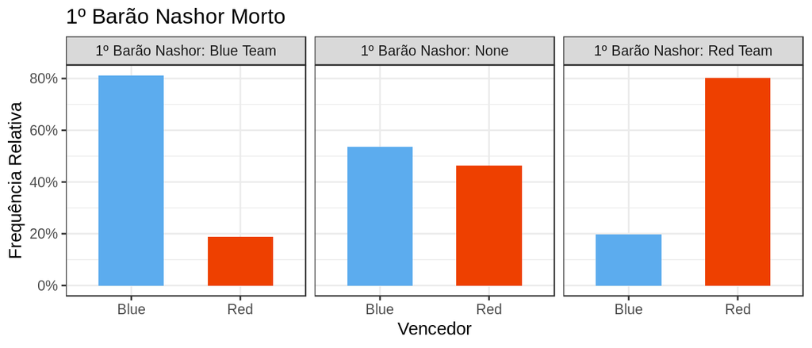

```r
ranked_matches %>%
  mutate(first_baron = case_when(first_baron == "Blue" ~ "1º Barão Nashor: Blue Team",
                                 first_baron == "Red" ~ "1º Barão Nashor: Red Team",
                                 TRUE ~ "1º Barão Nashor: None")) %>%
  ggplot(aes(x = winner, y = ..prop.., group = first_baron)) +
  geom_bar(aes(fill = factor(..x..)), width = .6, show.legend = FALSE) +
  labs(x = "Vencedor", y = "Frequência Relativa", title = "1º Barão Nashor Morto") +
  scale_y_continuous(labels = scales::percent_format(5L)) +
  scale_fill_manual(values = color_scale_2) +
  facet_grid(~ first_baron)
```

## Análises

Conforme os gráficos apresentados acima, o fato de um time sair vitorioso em uma partida ranqueada de *League of Legends* parece estar diretamente associado à sua capacidade de garantir a conquista dos primeiros objetivos do jogo. Essa relação será analisada mais profundamente com auxílio de regressão logística.

Inicialmente, cria-se um modelo linear generalizado que busca predizer qual dos times foi vitorioso baseando-se em qual deles conquistou o primeiro objetivo de cada tipo. A seguir, estão apresentadas algumas estatísticas encontradas para esse modelo.

```r
matches_glm <- glm(winner ~ first_tower + first_inhibitor + first_dragon + rift_herald_kill + first_baron,
          data = ranked_matches_factor,family = "binomial")

coefficients <- tidy(matches_glm, conf.int = TRUE) %>%
  select(-statistic, -p.value)

coefficients
```

| term | estimate | std.error | conf.low | conf.high |
| --- | --- | --- | --- | --- |
| (Intercept) | 4.0011568 | 0.04568910 | 3.912083347 | 4.0912094 |
| first_towerRed | -1.0161186 | 0.03055833 | -1.076053376 | -0.9562551 |
| first_inhibitorRed | -3.4709056 | 0.03288479 | -3.535644430 | -3.4067181 |
| first_dragonNone | 0.1825232 | 0.09336440 | -0.001138034 | 0.3649740 |
| first_dragonRed | -0.9153959 | 0.03036470 | -0.974960601 | -0.8559204 |
| rift_herald_killNone | -0.1936805 | 0.03704542 | -0.266293730 | -0.1210628 |
| rift_herald_killRed | -0.4482616 | 0.04450056 | -0.535508918 | -0.3610513 |
| first_baronNone | -0.3373264 | 0.03777733 | -0.411346493 | -0.2632456 |
| first_baronRed | -2.0902520 | 0.04016708 | -2.169157336 | -2.0116845 |

O modelo obtido está de acordo com a percepção de que conquistar os primeiros objetivos do jogo tem um impacto importante na definição de qual dos times será o vencedor da partida. Dos valores estimados, é possível gerar algumas considerações que serão simplificadas através da regra do “dividido por 4”. Essa regra indica que, ao dividir o valor de estimate por 4, encontra-se uma aproximação da diferença máxima na probabilidade analisada que uma unidade da variável independente causa. $^1$

```r
coefficients %>%
  mutate(`divided by 4 rule` = round((estimate / 4), 4)) %>%
  select(term, `divided by 4 rule`)
```

| term | divided by 4 rule |
| --- | --- |
| (Intercept) | 1.0003 |
| first_towerRed | -0.2540 |
| first_inhibitorRed | -0.8677 |
| first_dragonNone | 0.0456 |
| first_dragonRed | -0.2288 |
| rift_herald_killNone | -0.0484 |
| rift_herald_killRed | -0.1121 |
| first_baronNone | -0.0843 |
| first_baronRed | -0.5226 |

Considerando os valores calculados acima, sumariza-se as conclusões obtidas abaixo:

|  |  | Objetivo | Quem conquistou? | Impacto nas chances de vitória do Blue Team |
| --- | --- | --- | --- | --- |
|  |  | Arauto do Vale | Nenhum | **- 4,84%** |
|  |  | Arauto do Vale | *Red Team* | **- 11,21%** |
|  |  | 1º Barão Nashor | Nenhum | **- 8,43%** |
|  |  | 1º Barão Nashor | *Red Team* | **- 52,26%** |
|  |  | 1º Dragão | Nenhum | **+ 4,56%** |
|  |  | 1º Dragão | *Red Team* | **- 22,88%** |
|  |  | 1º Inibidor | *Red Team* | **- 86,77%** |
|  |  | 1ª Torre | *Red Team* | **- 25,40%** |

```r
tibble(statistic = c("Pseudo-R² de McFadden", "Pseudo-R² de Máxima Verossimilhança"),
       value = c(pR2(matches_glm)[4], pR2(matches_glm)[5]))
```

| statistic | value |
| --- | --- |
| Pseudo-R² de McFadden | 0.5524664 |
| Pseudo-R² de Máxima Verossimilhança | 0.5350357 |

Além disso, através de estatísticas como o Pseudo-R² de McFadden e o Pseudo-R² de Máxima Verossimilhança cujos valores estão apresentados acima, é possível afirmar que o modelo criado explica cerca de 54% das vitórias em partidas ranqueadas de *League of Legends* com base na conquista dos primeiros objetivos do jogo. Esse percentual é considerável, porém precisa de maiores refinamentos para tornar-se realmente adequado.

Através das variáveis independentes analisadas, é perceptível que o Barão *Nashor* e os inibidores são os objetivos com maior impacto sobre o resultado das partidas. Por fim, busca-se utilizar o modelo criado para prever os resultados das partidas cujos dados foram utilizados para as análises apresentadas.

```r
predictions <- matches_glm %>%
  augment(type.predict = "response") %>%
  mutate(predicted = .fitted > .5,  real = (winner == "Blue"))

predictions %>%
  mutate(matched = (predicted == real)) %>%
  group_by(matched) %>%
  summarise(occurrences = n(), percentage = (occurrences / NROW(predictions)))
```

| matched | occurrences | percentage |
| --- | --- | --- |
| FALSE | 6314 | 0.1255393 |
| TRUE | 43981 | 0.8744607 |

Percebe-se que o modelo criado foi muito bem sucedido para a amostra em questão, prevendo corretamente os resultados de 87,45% das partidas.

## Referências

$^1$ Andrew Gelman and Jennifer Hill. 2006. *Data analysis using regression and multilevel/hierarchical models*. Cambridge University Press.